# DM IntroDataScience

Imad Bendimerad

5/30/2022

### Installation des Packages

```r
#install.packages("caret")
#install.packages("doParallel")
#install.packages("parallel")
#install.packages("rpart")
#install.packages("rpart.plot")
#install.packages("rmarkdown")
```

## Jeu de données

```r
rm(list=ls())
cardio <- read.csv("processed.cleveland.data", header = FALSE, na.strings = '?')
names(cardio) <- c( "age", "sex", "cp", "trestbps", "chol",
                    "fbs", "restecg", "thalach","exang",
                    "oldpeak","slope", "ca", "thal", "status")
```

Lien du site des données de l’étude https://archive.ics.uci.edu/ml/datasets/heart+Disease

### 1 Appliquer la fonction str au data frame cardio. Les formats des variables du jeu de données sont-ils satisfaisants ?

```r
str(cardio)
```

```
## 'data.frame':    303 obs. of  14 variables:
##  $ age     : num  63 67 67 37 41 56 62 57 63 53 ...
##  $ sex     : num  1 1 1 1 0 1 0 0 1 1 ...
##  $ cp      : num  1 4 4 3 2 2 4 4 4 4 ...
##  $ trestbps: num  145 160 120 130 130 120 140 120 130 140 ...
##  $ chol    : num  233 286 229 250 204 236 268 354 254 203 ...
##  $ fbs     : num  1 0 0 0 0 0 0 0 0 1 ...
##  $ restecg : num  2 2 2 0 2 0 2 0 2 2 ...
##  $ thalach : num  150 108 129 187 172 178 160 163 147 155 ...
##  $ exang   : num  0 1 1 0 0 0 0 1 0 1 ...
##  $ oldpeak : num  2.3 1.5 2.6 3.5 1.4 0.8 3.6 0.6 1.4 3.1 ...
##  $ slope   : num  3 2 2 3 1 1 3 1 2 3 ...
##  $ ca      : num  0 3 2 0 0 0 2 0 1 0 ...
##  $ thal    : num  6 3 7 3 3 3 3 3 7 7 ...
##  $ status  : int  0 2 1 0 0 0 3 0 2 1 ...
```

Les variables “sex”, “cp”, “fbs”, “restecg”, “exang”, “slope”, “thal” et la variable réponse “status” sont codées autant que variables quantitatives alors qu’elles sont censées etre de nature qualitatives (on peut confirmer leurs natures sur le site) et donc les formats des variables des jeux de données ne sont pas satisfaisants

### 2 Transformation des variables explicatives qualitatives

Commençons par nous familiariser avec la fonction factor

```r
?factor
```

Transformation des variables explicatives qui sont de nature qualitative en codage catégorial

```r
cardio$sex <- factor( cardio$sex,levels = c(0, 1 ),
        labels = c( "Female","Male") )

cardio$cp <- factor( cardio$cp,levels = c(1, 2, 3, 4 ),
        labels = c( "typical angina","atypical angina","non-anginal pain","asymptomatic") )

cardio$fbs <- factor( cardio$fbs,levels = c(0, 1 ),
                      labels = c( "FBS < 120 mg/dl","FBS > 120 mg/dl") )

cardio$thal <- factor( cardio$thal,levels = c(3,6,7),
                      labels = c( "normal","fixed defect","reversable defect") )

cardio$slope <- factor( cardio$slope,levels = c(1,2,3),
                       labels = c( "upsloping","flat","downsloping") )

cardio$exang <- factor( cardio$exang,levels = c(0,1),
                        labels = c( "no","yes") )

cardio$restecg <- factor( cardio$restecg,levels = c(0,1,2),
                        labels = c( "normal","ST-T","LVH") )

cardio$status <- factor( cardio$status,levels = c(0, 1,2,3,4 ),
    labels = c("0", "1","2","3","4" ) )
```

On refait un str pour afin de vérifier la transformation

```r
str(cardio)
```

```
## 'data.frame':    303 obs. of  14 variables:
##  $ age     : num  63 67 67 37 41 56 62 57 63 53 ...
##  $ sex     : Factor w/ 2 levels "Female","Male": 2 2 2 2 1 2 1 1 2 2 ...
##  $ cp      : Factor w/ 4 levels "typical angina",..: 1 4 4 3 2 2 4 4 4 4 ...
##  $ trestbps: num  145 160 120 130 130 120 140 120 130 140 ...
##  $ chol    : num  233 286 229 250 204 236 268 354 254 203 ...
##  $ fbs     : Factor w/ 2 levels "FBS < 120 mg/dl",..: 2 1 1 1 1 1 1 1 1 2 ...
##  $ restecg : Factor w/ 3 levels "normal","ST-T",..: 3 3 3 1 3 1 3 1 3 3 ...
##  $ thalach : num  150 108 129 187 172 178 160 163 147 155 ...
##  $ exang   : Factor w/ 2 levels "no","yes": 1 2 2 1 1 1 1 2 1 2 ...
##  $ oldpeak : num  2.3 1.5 2.6 3.5 1.4 0.8 3.6 0.6 1.4 3.1 ...
##  $ slope   : Factor w/ 3 levels "upsloping","flat",..: 3 2 2 3 1 1 3 1 2 3 ...
##  $ ca      : num  0 3 2 0 0 0 2 0 1 0 ...
##  $ thal    : Factor w/ 3 levels "normal","fixed defect",..: 2 1 3 1 1 1 1 1 3 3 ...
##  $ status  : Factor w/ 5 levels "0","1","2","3",..: 1 3 2 1 1 1 4 1 3 2 ...
```

### 3 Quelles sont les modalités de la variable réponse ?

```r
levels(cardio$status)
```

```
## [1] "0" "1" "2" "3" "4"
```

Depuis l’article de reference on peut lire: ” The “goal” field refers to the presence of heart disease in the patient. It is integer valued from 0 (no presence) to 4. Experiments with the Cleveland database have concentrated on simply attempting to distinguish presence (values 1,2,3,4) from absence (value 0). ” D’ou on comprend que c’est possible de coder la variable réponse qualitative en binaire

### 4 Transformation de la variable réponse en binaire

```r
cardio$status <- factor( cardio$status,levels = c("0","1","2","3","4"),
                         labels = c( "0","1","1","1","1") )
```

```r
summary(cardio)
```

```
##       age            sex                     cp         trestbps
##  Min.   :29.00   Female: 97   typical angina  : 23   Min.   : 94.0
##  1st Qu.:48.00   Male  :206   atypical angina : 50   1st Qu.:120.0
##  Median :56.00                non-anginal pain: 86   Median :130.0
##  Mean   :54.44                asymptomatic    :144   Mean   :131.7
##  3rd Qu.:61.00                                       3rd Qu.:140.0
##  Max.   :77.00                                       Max.   :200.0
##
##       chol                    fbs        restecg       thalach      exang
##  Min.   :126.0   FBS < 120 mg/dl:258   normal:151   Min.   : 71.0   no :204
##  1st Qu.:211.0   FBS > 120 mg/dl: 45   ST-T  :  4   1st Qu.:133.5   yes: 99
##  Median :241.0                         LVH   :148   Median :153.0
##  Mean   :246.7                                      Mean   :149.6
##  3rd Qu.:275.0                                      3rd Qu.:166.0
##  Max.   :564.0                                      Max.   :202.0
##
##     oldpeak             slope           ca                        thal
##  Min.   :0.00   upsloping  :142   Min.   :0.0000   normal           :166
##  1st Qu.:0.00   flat       :140   1st Qu.:0.0000   fixed defect     : 18
##  Median :0.80   downsloping: 21   Median :0.0000   reversable defect:117
##  Mean   :1.04                     Mean   :0.6722   NA's             :  2
##  3rd Qu.:1.60                     3rd Qu.:1.0000
##  Max.   :6.20                     Max.   :3.0000
##                                   NA's   :4
##  status
##  0:164
##  1:139
##
##
##
##
##
```

### 5 Afficher le nombre de données manquantes du jeu de données. Écarter les données man- quantes à l’aide de la fonction na.omit

Nombre des données manquantes:

```r
na_count <- length(which(is.na(cardio)))
print(na_count)
```

```
## [1] 6
```

Utilisation de na.omit afin d’écarter les données manquantes enlevant les 6 lignes

```r
?na.omit
cardio <- na.omit(cardio)
```

## Modelisation

### 6 Fixer la graine du générateur aléatoire à 1 à l’aide de la fonction set.seed et répartir le jeu de données en jeux de données cardio.train et cardio.test de tailles respectives de 70% et 30%.

Fixation de la graine du générateur aléatoire (afin d’avoir un aléas controlé et identique pour une graine donnée)

```r
set.seed(1)
```

```r
train = sample(1:nrow(cardio), round(0.70*nrow(cardio)))
cardio.train = cardio[train,]
cardio.test = cardio[-train,]
```

### 7 Ajuster, tracer et comparer en terme d’erreur de test les arbres de décisions obtenus respec- tivement sans et avec élagage.

**CART sans élagage**

```r
require(rpart)
```

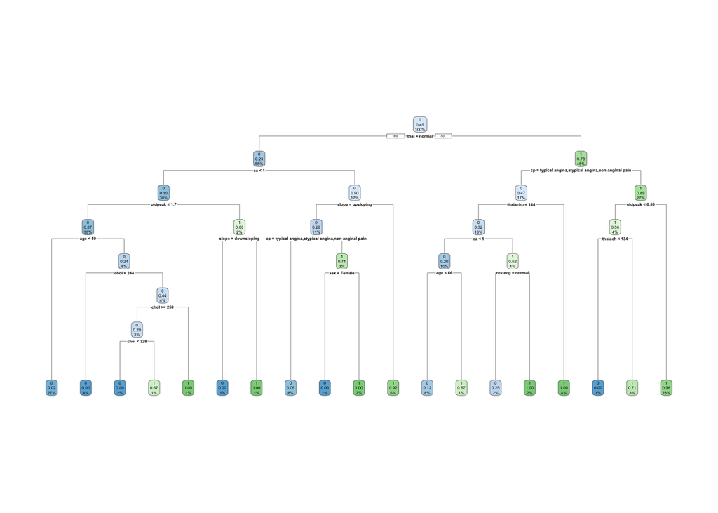

```r
require(rpart.plot)
set.seed(1)
cart.0 <- rpart(status~.,
                data=cardio.train,
                control=rpart.control(minsplit=5,cp=0, xval=5))

rpart.plot(cart.0)
```

```r
pred.0 <- predict(cart.0, cardio.test, type ="class")
TMC_sansE <- mean(pred.0!=cardio.test$status)
print(TMC_sansE)
```

```
## [1] 0.2808989
```

**CART avec élagage**

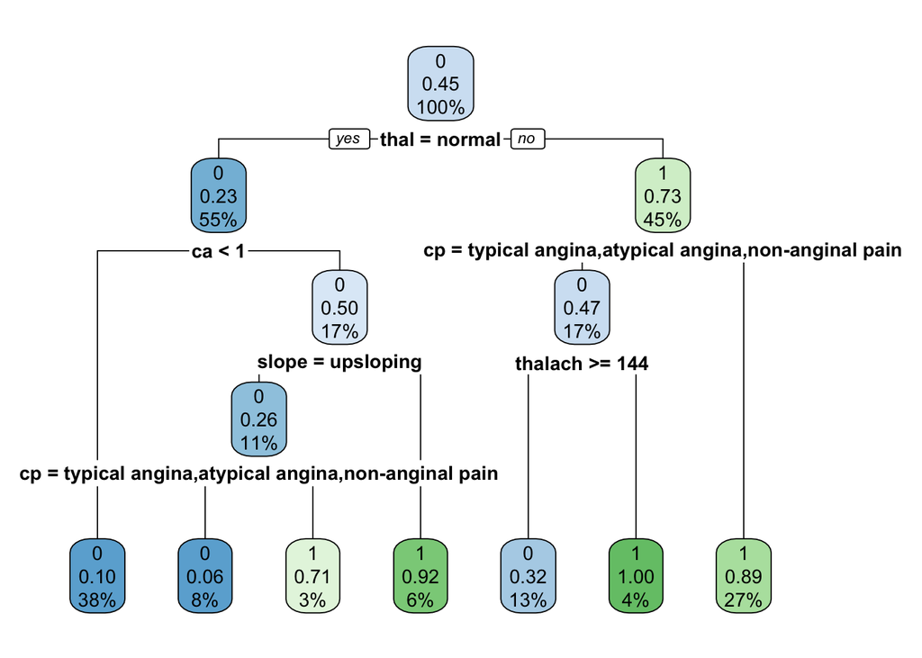

```r
cpOptim = cart.0$cptable[which.min(cart.0$cptable[,"xerror"]),"CP"]
cart.pruned <- prune(cart.0, cpOptim)
rpart.plot(cart.pruned)
```

```r
pred.pruned <- predict(cart.pruned, cardio.test, type ="class")
TMC_avecE <- mean(pred.pruned!=cardio.test$status)
print(TMC_avecE)
```

```
## [1] 0.2134831
```

#### Comparaisons

**Comparaison des erreurs de test des 2 modeles**

```r
print(TMC_sansE)
```

```
## [1] 0.2808989
```

```r
print(TMC_avecE)
```

```
## [1] 0.2134831
```

Le taux de mauvais classement est moindre dans le modele d’arbres de decision avec élagage

**les 2 arbres avec et sans élagage cote a cote**

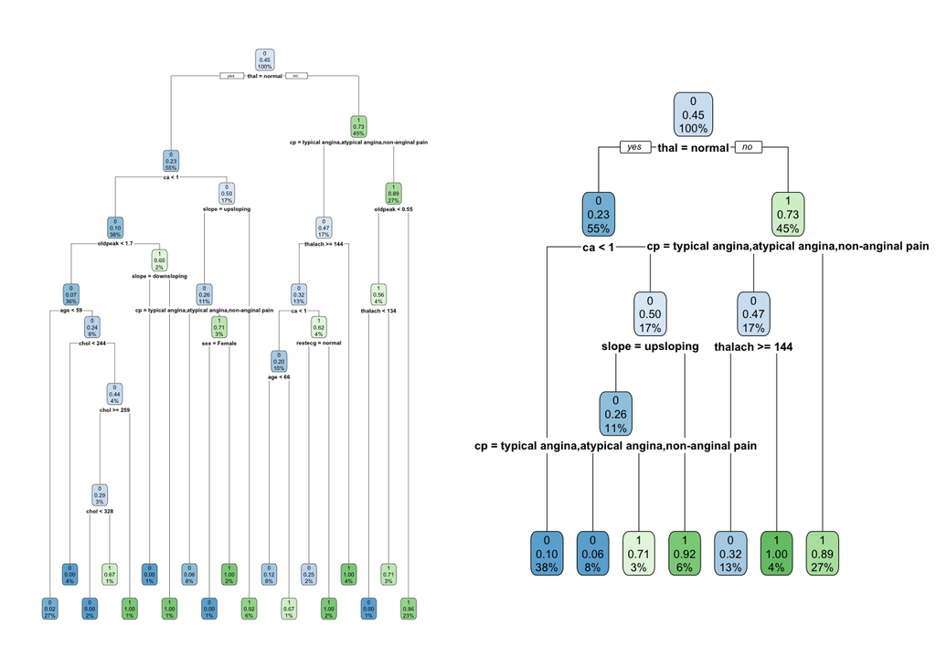

```r
par(mfrow = c(1, 2))
rpart.plot(cart.0)
rpart.plot(cart.pruned)
```

**Afficher l’importance relative de chaque variable explicative du modèle dans la prédiction de la variable réponse**

L’importance de chaque variable explicative du modèle sans élagage dans la prédiction de la variable réponse (de la plus importante vers la moins)

```r
cart.0$variable.importance
```

```
##   thalach      thal   oldpeak     slope        cp     exang        ca       sex
## 27.324008 26.952113 21.217215 18.147456 15.532239 10.639821 10.488346 10.422207
##       age      chol  trestbps   restecg       fbs
##  7.452678  7.182359  3.638883  2.323045  0.627451
```

```r
cart.0$variable.importance/sum(cart.0$variable.importance)
```

```
##     thalach        thal     oldpeak       slope          cp       exang
## 0.168721058 0.166424674 0.131012659 0.112057428 0.095908909 0.065699067
##          ca         sex         age        chol    trestbps     restecg
## 0.064763739 0.064355341 0.046019006 0.044349832 0.022469481 0.014344404
##         fbs
## 0.003874402
```

L’importance de chaque variable explicative du modèle avec élagage dans la prédiction de la variable réponse (de la plus importante vers la moins)

```r
cart.pruned$variable.importance
```

```
##      thal   thalach     slope   oldpeak        cp     exang        ca       sex
## 26.952113 21.929149 15.747456 14.350277 14.133137 10.639821  8.424061  7.052646
##       age  trestbps
##  2.622421  2.276267
```

```r
cart.pruned$variable.importance/sum(cart.pruned$variable.importance)
```

```
##       thal    thalach      slope    oldpeak         cp      exang         ca
## 0.21713276 0.17666654 0.12686532 0.11560931 0.11385998 0.08571697 0.06786627
##        sex        age   trestbps
## 0.05681783 0.02112686 0.01833816
```

on remarque qu’avec l’élagage on a des variables exclues, et l’importance des variables change

### 7 Peut-on améliorer les performances de prédiction à l’aide d’une forêt aléatoire à 500 arbres ?

Foret aléatoire avec caret tout en parralélisant les calcules sur les differents coeurs du CPU:

```r
require(caret)
require(doParallel)
require(parallel)
cl <- makePSOCKcluster(detectCores()-1)
registerDoParallel(cl)
control <- trainControl(method="repeatedcv", number=5, repeats=100)
rfGrid <-  expand.grid(mtry = 1:13)
RFmodel <- train(x = cardio.train[,-14],
                 y = cardio.train$status,
                 method="rf",
                 trControl=control,
                 n.trees=500,
                 tuneGrid = rfGrid)
stopCluster(cl)
pred.rf.caret <- predict(RFmodel, cardio.test)
TMC_RF <- mean(pred.rf.caret!=cardio.test$status)
print(TMC_RF)
```

```
## [1] 0.1797753
```

On a:

```r
TMC_RF<TMC_avecE
```

```
## [1] TRUE
```

D’ou on peut voir que le RandomForest peut améliorer les performances de prédiction face aux arbres de décision avec ou sans élagage